# Maximum Likelihood estimation of Spatial Seemingly Unrelated Regression models. A short Monte Carlo exercise with spsur and spse

Román Mínguez, University of Castilla-La Mancha (Spain)

Fernando A. López, Technical University of Cartagena (Spain)

Jesús Mur, University of Zaragoza, (Spain)

2025-09-02

# 1 A short Monte Carlo exercise: spsur vs spse.

The goal of this vignette is to present the results obtained in a Monte Carlo exercise to evaluate the performance of the Maximum Likelihood (ML) estimation of three spatial SUR models using the *R*-package **spsur** (Mínguez, López, and Mur 2022; López, Mı́nguez, and Mur 2020). The results will be compared with the same estimation using the **spse** *R*-package (Piras et al. 2010) when it is possible. We compare the two basic spatial SUR models, named SUR-SLM and SUR-SEM. In the case of SUR-SARAR, we only present the results obtained with **spsur** because the estimation of this model is not available with **spse**.

The design of the Monte Carlo is as follows: We simulate a spatial SUR model with two equations (G = 2), where each equation includes an intercept and two explanatory variables plus the corresponding spatial terms. For the general model the equation is:

$$\begin{equation}
y_i = (I_N-\rho_iW)^{-1}(\beta_{i0} + X_{i1}\beta_{i1} + X_{i2}\beta_{i2} + (I_N-\lambda_iW)^{-1}\epsilon_i); \ cov(\epsilon_i,\epsilon_j)=\sigma_{ij} ; \ i=1,2
\tag{1.1}
\end{equation}$$

Several combinations of parameters are selected to evaluate the performance of the ML algorithm under different levels of spatial dependence.

SUR-SLM: $(\rho_1,\rho_2)=(-0.4,0.6);(0.5,0.5);(0.2,0.8)$ and $(\lambda_1,\lambda_2)=(0,0)$

SUR-SEM: $(\rho_1,\rho_2)=(0,0)$ and $(\lambda_1,\lambda_2)=(-0.4,0.6);(0.5,0.5);(0.2,0.8)$

SUR-SARAR: $(\rho_1,\rho_2)=(\lambda_1,\lambda_2)=(-0.4,0.6);(0.5,0.5);(0.2,0.8)$

These spatial processes have been generated using the function *dgp_spsur()*, available in the **spsur** package. To evaluate the performance of the Maximum Likelihood estimation, we report bias and root mean-squared errors (RMSE) for all the combinations of the spatial parameters.

If **spsur** and **spse** needed to be installed, the first one is available in the CRAN repository and the second one can be installed from the following GitHub repository:

```r
# install_github("gpiras/spse",force = TRUE)
library(spse)
```

The package **sf** is used to generate hexagonal and regular lattices with the number of hexagons prefixed and **spdep** to obtain the **W** matrix based on a common border.

```r
library(sf)
library(spdep)
sfc <- st_sfc(st_polygon(list(rbind(c(0,0),c(1,0),c(1,1),c(0,1),c(0,0)))))
hexs.N52.sf <- st_sf(st_make_grid(sfc, cellsize = .19, square = FALSE))
hexs.N525.sf <- st_sf(st_make_grid(sfc, cellsize = .05, square = FALSE))
listw.N52 <- as(hexs.N52.sf, "Spatial") %>%
             poly2nb(queen = FALSE) %>% nb2listw()
listw.N525 <- as(hexs.N525.sf, "Spatial") %>%
              poly2nb(queen = FALSE) %>% nb2listw()
```

# 2 Maximum Likelihood estimation of SUR-SLM models

This section presents the results of a Monte Carlo exercise for the ML estimation of SUR-SLM models.

$$\begin{equation}
y_i = (I_N-\rho_iW)^{-1}(\beta_{i0} + X_{i1}\beta_{i1} + X_{i2}\beta_{i2} + \epsilon_i) \ ; \ cov(\epsilon_i,\epsilon_j)=\sigma_{ij} \ ; \ \ i=1,2
\tag{2.1}
\end{equation}$$

Table 1 shows the mean of the bias and the RMSE of the $\beta's$ and $\rho's$ parameters for the 1,000 replications. In general, all the results are coherent. The estimations with both *R*-packages show similar results. The highest bias is observed in the estimates of the intercept of the second equation for both packages. When the model is estimated with **spsur** the maximum bias is reached for N = 52 and when the model is estimated with **spse** the maximum bias corresponds to N = 516. In general, the results confirm that for both packages, the estimates of the parameters of spatial dependence present low biases. The RMSE values decrease when the sample size increases, as expected.

Table 1: SUR-SLM Bias and RMSE. Maximum Likelihood

| Pack | N | $\rho_1$ | $\rho_2$ | $\hat{\beta}_{10}$ | $\hat{\beta}_{11}$ | $\hat{\beta}_{12}$ | $\hat{\beta}_{20}$ | $\hat{\beta}_{21}$ | $\hat{\beta}_{22}$ | $\hat{\rho}_1$ | $\hat{\rho}_2$ |
| --- | --- | --- | --- | --- | --- | --- | --- | --- | --- | --- | --- |
| spsur | 52 | -0.4 | 0.6 | 0.009 | 0.001 | 0.001 | 0.036 | 0.001 | -0.004 | -0.007 | -0.012 |
|  |  |  |  | (0.156) | (0.126) | (0.126) | (0.208) | (0.133) | (0.132) | (0.077) | (0.054) |
|  |  | 0.5 | 0.5 | 0.027 | -0.002 | 0.001 | 0.027 | 0.001 | 0.000 | -0.012 | -0.011 |
|  |  |  |  | (0.201) | (0.129) | (0.129) | (0.199) | (0.132) | (0.126) | (0.061) | (0.059) |
|  |  | 0.2 | 0.8 | 0.017 | -0.006 | -0.001 | 0.065 | 0.006 | 0.002 | -0.011 | -0.012 |
|  |  |  |  | (0.178) | (0.124) | (0.126) | (0.276) | (0.129) | (0.126) | (0.071) | (0.040) |
|  | 516 | -0.4 | 0.6 | -0.002 | 0.000 | -0.000 | 0.001 | 0.002 | 0.001 | -0.002 | -0.001 |
|  |  |  |  | (0.047) | (0.038) | (0.040) | (0.058) | (0.040) | (0.041) | (0.025) | (0.015) |
|  |  | 0.5 | 0.5 | 0.000 | -0.001 | 0.001 | -0.001 | -0.001 | -0.001 | -0.001 | -0.001 |
|  |  |  |  | (0.057) | (0.039) | (0.041) | (0.058) | (0.039) | (0.041) | (0.017) | (0.017) |
|  |  | 0.2 | 0.8 | 0.003 | 0.001 | -0.000 | 0.007 | 0.001 | 0.000 | -0.001 | -0.001 |
|  |  |  |  | (0.052) | (0.038) | (0.039) | (0.068) | (0.038) | (0.040) | (0.022) | (0.010) |
| spse | 52 | -0.4 | 0.6 | 0.018 | -0.001 | -0.002 | 0.007 | -0.004 | -0.009 | -0.021 | -0.001 |
|  |  |  |  | (0.159) | (0.143) | (0.143) | (0.205) | (0.147) | (0.144) | (0.083) | (0.054) |
|  |  | 0.5 | 0.5 | 0.002 | -0.003 | -0.003 | 0.005 | -0.003 | -0.005 | 0.000 | 0.000 |
|  |  |  |  | (0.201) | (0.149) | (0.146) | (0.200) | (0.150) | (0.141) | (0.063) | (0.061) |
|  |  | 0.2 | 0.8 | 0.011 | -0.002 | -0.004 | 0.008 | -0.001 | -0.009 | -0.006 | -0.001 |
|  |  |  |  | (0.180) | (0.143) | (0.149) | (0.267) | (0.149) | (0.153) | (0.074) | (0.039) |
|  | 516 | -0.4 | 0.6 | 0.007 | -0.001 | -0.004 | -0.025 | -0.002 | -0.003 | -0.014 | 0.009 |
|  |  |  |  | (0.049) | (0.044) | (0.045) | (0.063) | (0.046) | (0.048) | (0.030) | (0.018) |
|  |  | 0.5 | 0.5 | -0.021 | -0.003 | -0.003 | -0.022 | -0.004 | -0.003 | 0.010 | 0.010 |
|  |  |  |  | (0.061) | (0.045) | (0.047) | (0.063) | (0.045) | (0.046) | (0.020) | (0.020) |
|  |  | 0.2 | 0.8 | -0.004 | 0.000 | -0.001 | -0.039 | -0.005 | -0.007 | 0.004 | 0.008 |
|  |  |  |  | (0.053) | (0.044) | (0.044) | (0.078) | (0.043) | (0.045) | (0.023) | (0.013) |

Figure 1 shows the boxplots of $\gamma_{ij}=\hat\beta_{ij}^{spsur}-\hat\beta_{ij}^{spse}$ and $\delta_i=\hat\rho_{i}^{spsur}-\hat\rho_{i}^{spse}$, the difference between estimated parameters ‘model to model’ for N = 516 (the superscript indicates the package used to estimate the coefficient). These boxplots confirm that the main differences are founded in the intercept of the second equation.

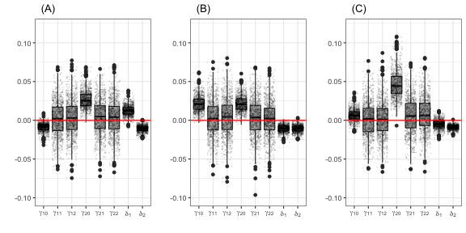

Figure 1: Difference between parameters ‘model to model’ SUR-SLM (N=516). (A) $\rho_1=-0.4; \rho_2=0.6$ ; (B) $\rho_1=0.5; \rho_2=0.5$ ; (C) $\rho_1 = 0.2; \rho_2 = 0.8$

# 3 Maximum Likelihood estimation of SUR-SEM models

Table 2: Bias and RMSE. SUR-SEM Maximum Likelihood

| Pack | N | $\lambda_1$ | $\lambda_2$ | $\hat{\beta}_{10}$ | $\hat{\beta}_{11}$ | $\hat{\beta}_{12}$ | $\hat{\beta}_{20}$ | $\hat{\beta}_{21}$ | $\hat{\beta}_{22}$ | $\hat{\lambda}_1$ | $\hat{\lambda}_2$ |
| --- | --- | --- | --- | --- | --- | --- | --- | --- | --- | --- | --- |
| spsur | 52 | -0.4 | 0.6 | 0.004 | 0.005 | 0.003 | 0.008 | 0.002 | -0.006 | -0.071 | -0.080 |
|  |  |  |  | (0.103) | (0.127) | (0.122) | (0.357) | (0.128) | (0.124) | (0.239) | (0.174) |
|  |  | 0.5 | 0.5 | 0.006 | -0.001 | 0.003 | 0.006 | -0.001 | 0.001 | -0.070 | -0.086 |
|  |  |  |  | (0.289) | (0.125) | (0.126) | (0.286) | (0.126) | (0.123) | (0.186) | (0.190) |
|  |  | 0.2 | 0.8 | 0.003 | -0.003 | 0.000 | 0.021 | 0.002 | -0.003 | -0.082 | -0.074 |
|  |  |  |  | (0.174) | (0.123) | (0.127) | (0.688) | (0.117) | (0.115) | (0.228) | (0.138) |
|  | 516 | -0.4 | 0.6 | -0.002 | 0.001 | -0.000 | -0.004 | 0.002 | 0.001 | -0.008 | -0.008 |
|  |  |  |  | (0.030) | (0.037) | (0.039) | (0.110) | (0.038) | (0.039) | (0.073) | (0.046) |
|  |  | 0.5 | 0.5 | -0.004 | -0.001 | 0.001 | -0.007 | -0.001 | -0.001 | -0.005 | -0.009 |
|  |  |  |  | (0.089) | (0.038) | (0.040) | (0.091) | (0.038) | (0.040) | (0.050) | (0.052) |
|  |  | 0.2 | 0.8 | 0.001 | 0.001 | 0.000 | 0.015 | 0.000 | 0.000 | -0.010 | -0.007 |
|  |  |  |  | (0.055) | (0.038) | (0.038) | (0.225) | (0.035) | (0.037) | (0.063) | (0.031) |
| spse | 52 | -0.4 | 0.6 | 0.004 | 0.005 | 0.004 | 0.008 | 0.002 | -0.007 | -0.033 | -0.107 |
|  |  |  |  | (0.103) | (0.126) | (0.122) | (0.357) | (0.129) | (0.125) | (0.214) | (0.185) |
|  |  | 0.5 | 0.5 | 0.006 | -0.001 | 0.003 | 0.006 | -0.001 | 0.001 | -0.091 | -0.106 |
|  |  |  |  | (0.289) | (0.126) | (0.126) | (0.286) | (0.127) | (0.123) | (0.190) | (0.195) |
|  |  | 0.2 | 0.8 | 0.003 | -0.003 | 0.001 | 0.022 | 0.001 | -0.003 | -0.087 | -0.103 |
|  |  |  |  | (0.174) | (0.122) | (0.126) | (0.687) | (0.118) | (0.117) | (0.218) | (0.158) |
|  | 516 | -0.4 | 0.6 | -0.002 | 0.001 | -0.000 | -0.004 | 0.002 | 0.001 | -0.005 | -0.011 |
|  |  |  |  | (0.030) | (0.037) | (0.039) | (0.110) | (0.038) | (0.039) | (0.072) | (0.046) |
|  |  | 0.5 | 0.5 | -0.004 | -0.001 | 0.001 | -0.007 | -0.001 | -0.001 | -0.008 | -0.012 |
|  |  |  |  | (0.089) | (0.038) | (0.040) | (0.091) | (0.038) | (0.040) | (0.050) | (0.053) |
|  |  | 0.2 | 0.8 | 0.001 | 0.001 | 0.000 | 0.015 | 0.000 | 0.000 | -0.011 | -0.009 |
|  |  |  |  | (0.055) | (0.038) | (0.038) | (0.225) | (0.035) | (0.037) | (0.063) | (0.032) |

As in the case of SUR-SLM, the Figure 2 shows the difference between the parameters estimated with **spsur** and **spse** for N = 516. These boxplots show that the biases in the SUR-SEM are lower than in the SUR-SLM for all the parameters.

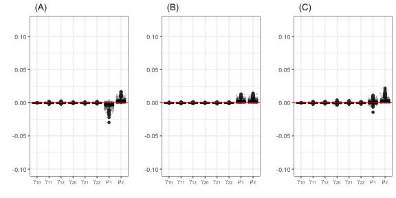

Figure 2: Difference between parameters ‘model to model’ SUR-SEM N=516. (A) $\lambda_1=-0.4; \lambda_2=0.6$ ; (B) $\lambda_1=0.5; \lambda_2=0.5$ ; (C) $\lambda_1 = 0.2; \lambda_2 = 0.8$

# 4 Maximum Likelihood estimation of SUR-SARAR models

Table 3 shows the results obtained for the bias and RMSE for the LM estimation of SUR-SARAR models. For this model, only the results obtained with the **spsur** package can be shown because this specification is not available for the **spse** package. As in the case of the estimations of the SUR-SLM and SUR-SEM models the worst results in terms of bias and RMSE are obtained when the sample size is small (N = 52). In the case of N = 52 the $\lambda's$ parameters are underestimated. This underestimation disappears when the sample size is medium (N = 516).

Table 3: SUR-SARAR Bias and RMSE (in brackets). Maximum Likelihood with spsur

| N | $\rho_1;\lambda_1$ | $\rho_2;\lambda_2$ | $\hat\beta_{10}$ | $\hat\beta_{11}$ | $\hat\beta_{12}$ | $\hat\beta_{20}$ | $\hat\beta_{21}$ | $\hat\beta_{22}$ | $\hat\rho_1$ | $\hat\rho_2$ | $\hat\lambda_1$ | $\hat\lambda_2$ |
| --- | --- | --- | --- | --- | --- | --- | --- | --- | --- | --- | --- | --- |
| 52 | -0.4 | 0.6 | 0.005 | 0.003 | 0.002 | 0.032 | -0.002 | -0.012 | -0.003 | -0.009 | -0.077 | -0.104 |
| 52 | -0.4 | 0.6 | (0.121) | (0.127) | (0.124) | (0.439) | (0.133) | (0.131) | (0.080) | (0.083) | (0.252) | (0.210) |
| 52 | 0.5 | 0.5 | 0.027 | -0.007 | -0.005 | 0.014 | -0.003 | -0.004 | -0.010 | -0.003 | -0.094 | -0.117 |
| 52 | 0.5 | 0.5 | (0.365) | (0.130) | (0.129) | (0.345) | (0.130) | (0.128) | (0.089) | (0.084) | (0.229) | (0.231) |
| 52 | 0.2 | 0.8 | 0.010 | -0.007 | -0.004 | 0.098 | -0.002 | -0.009 | -0.006 | -0.013 | -0.103 | -0.093 |
| 52 | 0.2 | 0.8 | (0.214) | (0.126) | (0.127) | (0.931) | (0.122) | (0.123) | (0.083) | (0.080) | (0.253) | (0.177) |
| 516 | -0.4 | 0.6 | -0.001 | 0.001 | -0.000 | -0.002 | 0.002 | 0.000 | -0.001 | -0.001 | -0.008 | -0.010 |
| 516 | -0.4 | 0.6 | (0.036) | (0.037) | (0.039) | (0.127) | (0.039) | (0.040) | (0.025) | (0.026) | (0.076) | (0.053) |
| 516 | 0.5 | 0.5 | -0.002 | -0.001 | 0.000 | -0.006 | -0.001 | -0.002 | -0.001 | -0.001 | -0.008 | -0.012 |
| 516 | 0.5 | 0.5 | (0.106) | (0.038) | (0.041) | (0.106) | (0.038) | (0.041) | (0.026) | (0.026) | (0.058) | (0.059) |
| 516 | 0.2 | 0.8 | 0.002 | 0.001 | -0.000 | 0.021 | -0.000 | -0.001 | -0.000 | -0.001 | -0.013 | -0.009 |
| 516 | 0.2 | 0.8 | (0.064) | (0.038) | (0.038) | (0.262) | (0.036) | (0.038) | (0.025) | (0.025) | (0.070) | (0.041) |

# 5 Conclusion

This vignette shows the results of a sort Monte Carlo exercise to evaluate the ML estimation of three spatial SUR models, SUR-SLM, SUR-SEM, and SUR-SARAR. The first two models are estimated with the **spsur** and **spse** packages and the results are compared. In the case of the SUR-SARAR model only the results using the **spsur** are presented because the estimation of SUR-SARAR is no available.

In general, both packages present admissible results. When comparing the estimates of the coefficients for SUR-SLM some differences emerge, mainly in the estimation of the intercepts. In the case of SUR-SEM both *R*-packages give similar results for small and medium sample sizes.

A full Monte Carlo using irregular lattices, alternative **W** matrices, and non-ideal conditions would shed more light on the performance of the ML algorithm implemented in both *R*-packages.

# References

López, Fernando A, Román Mı́nguez, and Jesús Mur. 2020. “ML Versus IV Estimates of Spatial SUR Models: Evidence from the Case of Airbnb in Madrid Urban Area.” *The Annals of Regional Science* 64 (2): 313–47. https://doi.org/10.1007/s00168-019-00914-1.

Mínguez, Román, Fernando A. López, and Jesús Mur. 2022. “spsur: An R Package for Dealing with Spatial Seemingly Unrelated Regression Models.” *Journal of Statistical Software* 104 (11): 1–43. https://doi.org/10.18637/jss.v104.i11.

Piras, Gianfranco et al. 2010. “sphet: Spatial Models with Heteroskedastic Innovations in R.” *Journal of Statistical Software* 35 (1): 1–21. https://doi.org/10.18637/jss.v035.i01.